# G1401231094-Kamal Aldimas-Tugas 2 MPDW

2025-09-02

```r
library(dplyr)
library(TTR)
library(forecast)
library(lmtest)
library(orcutt) #untuk membuat model regresi Cochrane-Orcutt
library(HoRM) #untuk membuat model regresi Hildreth-Lu
```

# Input Data

```r
# Input data
  Tahun = c(2012, 2013, 2014, 2015, 2016, 2017,2018, 2019, 2020, 2021, 2022, 2023, 2024)

  IPM = c(64.18, 64.57, 65.20, 67.13, 67.85, 68.39, 69.11, 69.87, 69.87, 70.12, 70.85, 71.45, 71.99)
data <- cbind(Tahun, IPM)
data <-as.data.frame(data)
data
```

```
##    Tahun   IPM
## 1   2012 64.18
## 2   2013 64.57
## 3   2014 65.20
## 4   2015 67.13
## 5   2016 67.85
## 6   2017 68.39
## 7   2018 69.11
## 8   2019 69.87
## 9   2020 69.87
## 10  2021 70.12
## 11  2022 70.85
## 12  2023 71.45
## 13  2024 71.99
```

# Eksplorasi Data

Objek Time Series

```r
data.ts<-ts(data$IPM)
data.ts
```

```
## Time Series:
## Start = 1
## End = 13
## Frequency = 1
##  [1] 64.18 64.57 65.20 67.13 67.85 68.39 69.11 69.87 69.87 70.12 70.85 71.45
## [13] 71.99
```

Plot Time Series

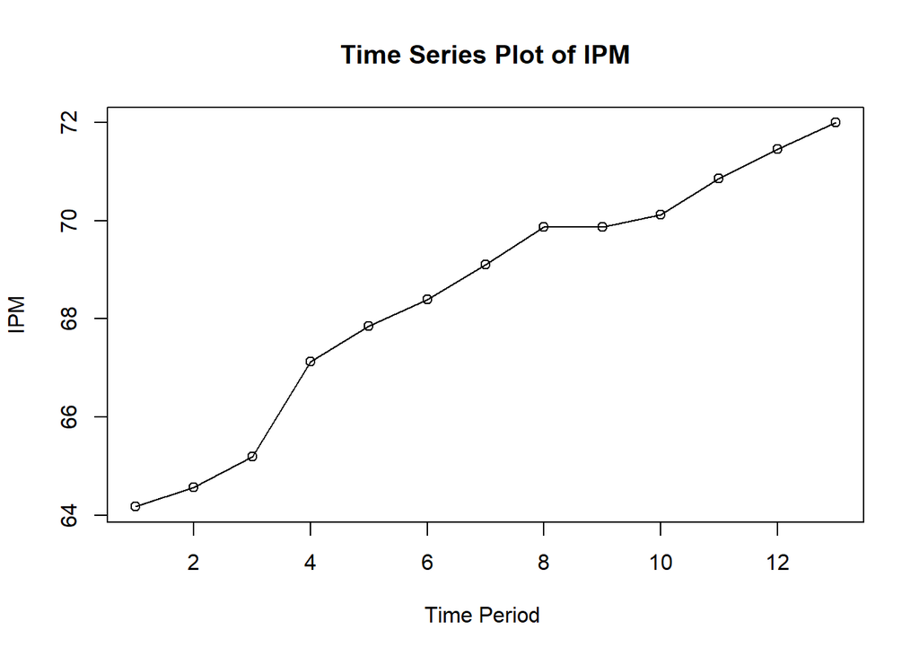

```r
ts.plot(data.ts, xlab="Time Period ", ylab="IPM", main= "Time Series Plot of IPM")
points(data.ts)
```

Metode DMA dan DES

```r
dt.sma <- SMA(data.ts, n=3)
dma <- SMA(dt.sma, n = 3)
At <- 2*dt.sma - dma
Bt <- 2/(3-1)*(dt.sma - dma)
dt.dma<- At+Bt
dt.ramal<- c(NA, dt.dma)

t = 1:5
f = c()

for (i in t) {
  f[i] = At[length(At)] + Bt[length(Bt)]*(i)
}
```

```r
dt.gab <- cbind(aktual = c(data.ts,rep(NA,5)),
                pemulusan1 = c(dt.sma,rep(NA,5)),
                pemulusan2 = c(dt.dma, rep(NA,5)),
                At = c(At, rep(NA,5)),
                Bt = c(Bt,rep(NA,5)),
                ramalan = c(dt.ramal, f[-1]))
dt.gab
```

```
##       aktual pemulusan1 pemulusan2       At        Bt  ramalan
##  [1,]  64.18         NA         NA       NA        NA       NA
##  [2,]  64.57         NA         NA       NA        NA       NA
##  [3,]  65.20   64.65000         NA       NA        NA       NA
##  [4,]  67.13   65.63333         NA       NA        NA       NA
##  [5,]  67.85   66.72667   68.84000 67.78333 1.0566667       NA
##  [6,]  68.39   67.79000   69.93667 68.86333 1.0733333 68.84000
##  [7,]  69.11   68.45000   70.03889 69.24444 0.7944444 69.93667
##  [8,]  69.87   69.12333   70.46111 69.79222 0.6688889 70.03889
##  [9,]  69.87   69.61667   70.72333 70.17000 0.5533333 70.46111
## [10,]  70.12   69.95333   70.73111 70.34222 0.3888889 70.72333
## [11,]  70.85   70.28000   70.94000 70.61000 0.3300000 70.73111
## [12,]  71.45   70.80667   71.72667 71.26667 0.4600000 70.94000
## [13,]  71.99   71.43000   72.61222 72.02111 0.5911111 71.72667
## [14,]     NA         NA         NA       NA        NA 72.61222
## [15,]     NA         NA         NA       NA        NA 73.20333
## [16,]     NA         NA         NA       NA        NA 73.79444
## [17,]     NA         NA         NA       NA        NA 74.38556
## [18,]     NA         NA         NA       NA        NA 74.97667
```

Plot Time Series

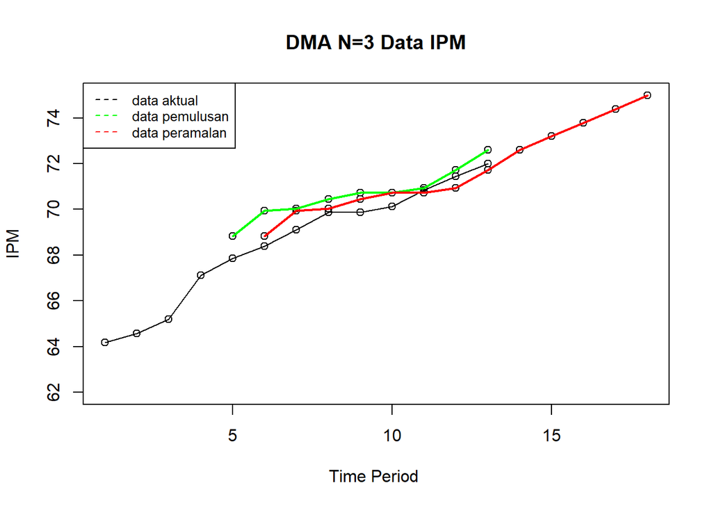

```r
#Plot time series
ts.plot(dt.gab[,1], xlab="Time Period ", ylab="IPM",
        main= "DMA N=3 Data IPM", ylim=c(62,75))
points(dt.gab[,1])
points(dt.gab[,3])
points(dt.gab[,6])
lines(dt.gab[,3],col="green",lwd=2)
lines(dt.gab[,6],col="red",lwd=2)
legend("topleft",c("data aktual","data pemulusan","data peramalan"),
       lty=8, col=c("black","green","red"), cex=0.8)
```

Metode DMA

```r
#Menghitung nilai keakuratan
error.dma = data.ts-dt.ramal[1:length(data.ts)]
SSE.dma = sum(error.dma[6:length(data.ts)]^2)
MSE.dma = mean(error.dma[6:length(data.ts)]^2)
MAPE.dma = mean(abs((error.dma[6:length(data.ts)]/data.ts[6:length(data.ts)])*100))

akurasi.dma <- matrix(c(SSE.dma, MSE.dma, MAPE.dma))
row.names(akurasi.dma)<- c("SSE", "MSE", "MAPE")
colnames(akurasi.dma) <- c("Akurasi m = 3")
akurasi.dma
```

```
##      Akurasi m = 3
## SSE      1.9714037
## MSE      0.2464255
## MAPE     0.6312121
```

Double Exponential Smoothing

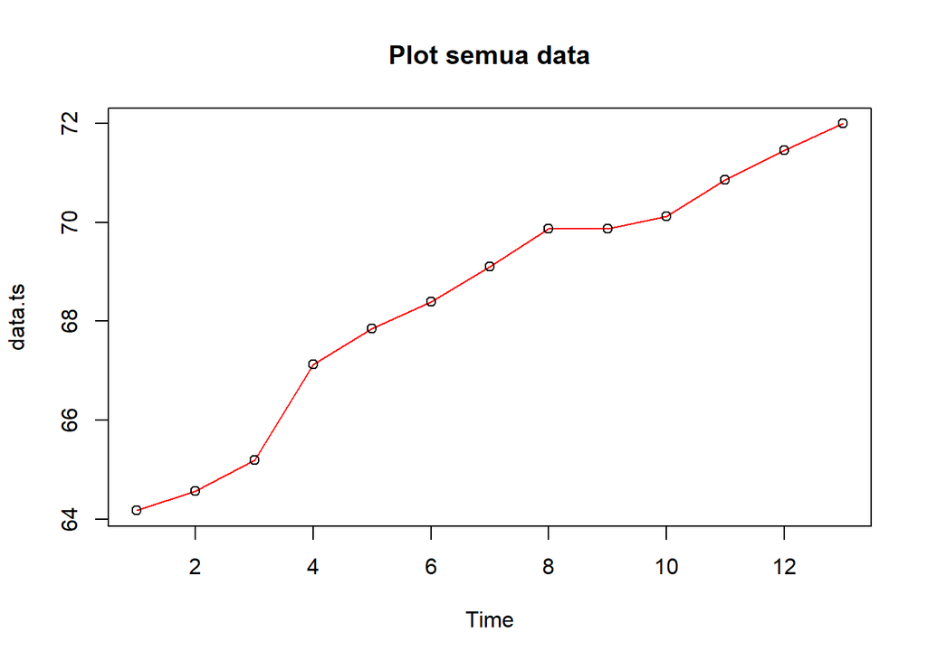

```r
#membagi training dan testing
training<-data[1:11,2]
testing<-data[12:13,2]

#data time series
training.ts<-ts(training)
testing.ts<-ts(testing,start=11)

#eksplorasi data
plot(data.ts, col="red",main="Plot semua data")
points(data.ts)
```

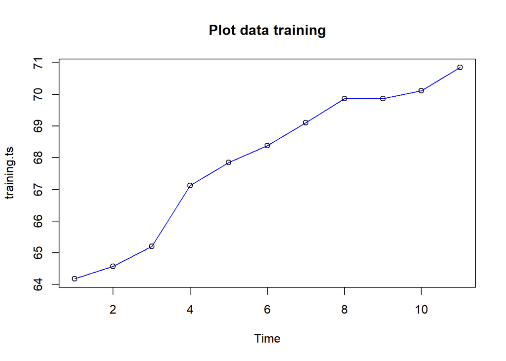

```r
plot(training.ts, col="blue",main="Plot data training")
points(training.ts)
```

Pemulusan dengan DES

```r
#Lamda dan gamma optimum
des.opt<- HoltWinters(training.ts, gamma = FALSE)
des.opt
```

```
## Holt-Winters exponential smoothing with trend and without seasonal component.
##
## Call:
## HoltWinters(x = training.ts, gamma = FALSE)
##
## Smoothing parameters:
##  alpha: 1
##  beta : 0.09573913
##  gamma: FALSE
##
## Coefficients:
##         [,1]
## a 70.8500000
## b  0.5363335
```

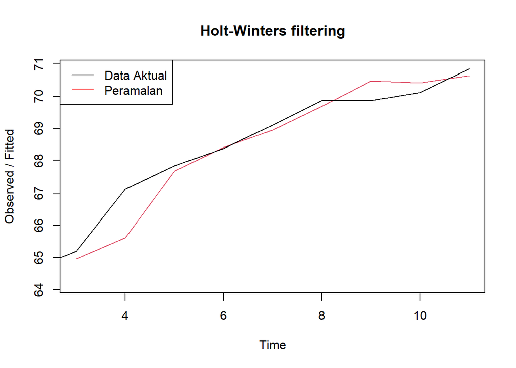

```r
plot(des.opt)
legend("topleft", c("Data Aktual", "Peramalan"), col = c("black", "red"),
       lty = c(1,1))
```

Ramalan

```r
#ramalan
ramalandesopt<- forecast(des.opt, h=5)
ramalandesopt
```

```
##    Point Forecast    Lo 80    Hi 80    Lo 95    Hi 95
## 12       71.38633 70.64542 72.12724 70.25321 72.51946
## 13       71.92267 70.82356 73.02177 70.24173 73.60361
## 14       72.45900 71.04927 73.86873 70.30301 74.61499
## 15       72.99533 71.29331 74.69736 70.39231 75.59836
## 16       73.53167 71.54501 75.51832 70.49334 76.56999
```

Metode DES

```r
ssedes.train<-des.opt$SSE
msedes.train<-ssedes.train/length(training.ts)
sisaandes<-ramalandesopt$residuals
head(sisaandes)
```

```
## Time Series:
## Start = 1
## End = 6
## Frequency = 1
## [1]         NA         NA  0.2400000  1.5170226  0.1617842 -0.0337049
```

```r
mapedes.train <- sum(abs(sisaandes[3:length(training.ts)]/training.ts[3:length(training.ts)])*100)/length(training.ts)

akurasides.opt <- matrix(c(ssedes.train,msedes.train,mapedes.train))
row.names(akurasides.opt)<- c("SSE", "MSE", "MAPE")
colnames(akurasides.opt) <- c("Akurasi lamda dan gamma optimum")
akurasides.opt
```

```
##      Akurasi lamda dan gamma optimum
## SSE                        2.9334950
## MSE                        0.2666814
## MAPE                       0.4513892
```

```r
#Akurasi data testing
selisihdesopt<-ramalandesopt$mean-testing.ts
selisihdesopt
```

```
## Time Series:
## Start = 12
## End = 12
## Frequency = 1
## ramalandesopt$mean
##         -0.6036665
```

```r
SSEtestingdesopt<-sum(selisihdesopt^2)
SSEtestingdesopt<-SSEtestingdesopt/length(testing.ts)
MAPEtestingdesopt<-sum(abs(selisihdesopt/testing.ts)*100)/length(testing.ts)

akurasiDesTesting <- matrix(c(SSEtestingdesopt,SSEtestingdesopt,MAPEtestingdesopt))
row.names(akurasiDesTesting)<- c("SSE", "MSE", "MAPE")
colnames(akurasiDesTesting) <- c("Akurasi lamda dan gamma optimum")
akurasiDesTesting
```

```
##      Akurasi lamda dan gamma optimum
## SSE                        0.1822066
## MSE                        0.1822066
## MAPE                       0.4192711
```

```r
cbind(akurasi.dma, akurasides.opt)
```

```
##      Akurasi m = 3 Akurasi lamda dan gamma optimum
## SSE      1.9714037                       2.9334950
## MSE      0.2464255                       0.2666814
## MAPE     0.6312121                       0.4513892
```

Scatter Plot

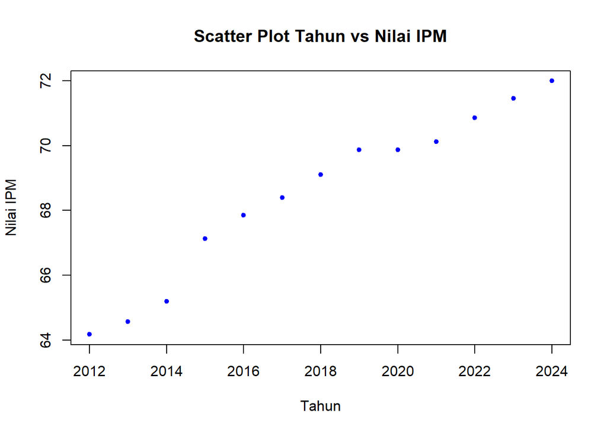

```r
plot(data$Tahun, data$IPM,
     pch = 20, col = "blue",
     main = "Scatter Plot Tahun vs Nilai IPM",
     xlab = "Tahun", ylab = "Nilai IPM")
```

```r
cor(Tahun, IPM)
```

```
## [1] 0.9779858
```

Berdasarkan scatter plot di atas, terlihat adanya hubungan / korelasi positif antara peubah tahun dengan nilai IPM, terlihat titik-titik pada plot yang naik ke arah kanan atas. Hal tersebut juga diperkuat dengan hasil perhitungan aplikasi R di mana didapatkan nilai korelasi sebesar 0.9779858

# Regresi

```r
#Pembuatan Model Regresi
#model regresi
model<- lm(IPM~Tahun, data = data)
summary(model)
```

```
##
## Call:
## lm(formula = IPM ~ Tahun, data = data)
##
## Residuals:
##     Min      1Q  Median      3Q     Max
## -0.7050 -0.4178 -0.2572  0.5747  0.7136
##
## Coefficients:
##               Estimate Std. Error t value Pr(>|t|)
## (Intercept) -1.244e+03  8.442e+01  -14.73 1.38e-08 ***
## Tahun        6.503e-01  4.183e-02   15.54 7.83e-09 ***
## ---
## Signif. codes:  0 '***' 0.001 '**' 0.01 '*' 0.05 '.' 0.1 ' ' 1
##
## Residual standard error: 0.5644 on 11 degrees of freedom
## Multiple R-squared:  0.9565, Adjusted R-squared:  0.9525
## F-statistic: 241.6 on 1 and 11 DF,  p-value: 7.828e-09
```

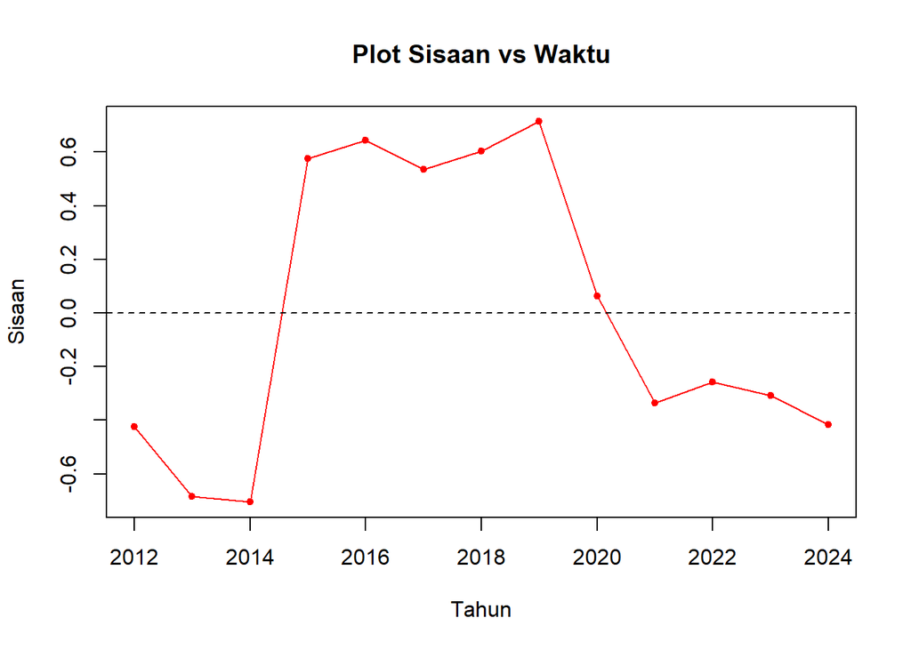

```r
# Ambil sisaan dari model
sisaan_awal <- residuals(model)

# Plot sisaan terhadap waktu
plot(data$Tahun, sisaan_awal, type="o", pch=20, col="red",
     main="Plot Sisaan vs Waktu", xlab="Tahun", ylab="Sisaan")
abline(h=0, lty=2) # Garis referensi di y=0
```

```r
dwtest(model)
```

```
##
##  Durbin-Watson test
##
## data:  model
## DW = 0.66898, p-value = 0.0003922
## alternative hypothesis: true autocorrelation is greater than 0
```

p-value yg dihasilkan dibawah signifikansi 0.05 kesimpulannya maka menolak H0 bukti sudah kuat model terbukti ada autokorelasi

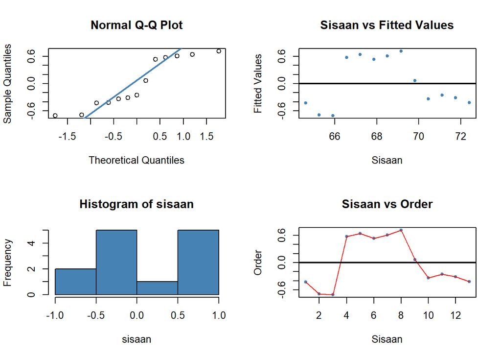

```r
#sisaan dan fitted value
sisaan<- residuals(model)
fitValue<- predict(model)

#Diagnostik dengan eksploratif
par(mfrow = c(2,2))
qqnorm(sisaan)
qqline(sisaan, col = "steelblue", lwd = 2)
plot(fitValue, sisaan, col = "steelblue", pch = 20, xlab = "Sisaan", ylab = "Fitted Values", main = "Sisaan vs Fitted Values")
abline(a = 0, b = 0, lwd = 2)
hist(sisaan, col = "steelblue")
plot(seq(1,13,1), sisaan, col = "steelblue", pch = 20, xlab = "Sisaan", ylab = "Order", main = "Sisaan vs Order")
lines(seq(1,13,1), sisaan, col = "red")
abline(a = 0, b = 0, lwd = 2)
```

```r
#Melihat Sisaan Menyebar Normal/Tidak
#H0: sisaan mengikuti sebaran normal
#H1: sisaan tidak mengikuti sebaran normal
shapiro.test(sisaan)
```

```
##
##  Shapiro-Wilk normality test
##
## data:  sisaan
## W = 0.85965, p-value = 0.03812
```

```r
ks.test(sisaan, "pnorm", mean=mean(sisaan), sd=sd(sisaan))
```

```
##
##  Exact one-sample Kolmogorov-Smirnov test
##
## data:  sisaan
## D = 0.22316, p-value = 0.4701
## alternative hypothesis: two-sided
```

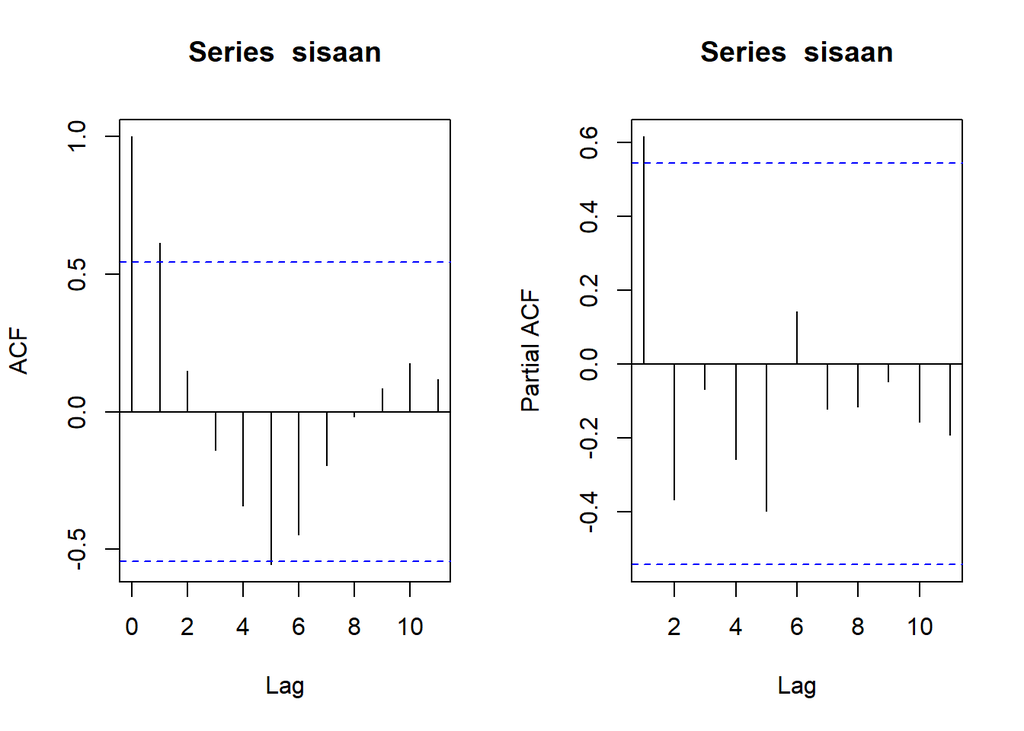

```r
#ACF dan PACF identifikasi autokorelasi
par(mfrow = c(1,2))
acf(sisaan)
pacf(sisaan)
```

```r
#Deteksi autokorelasi dengan uji-Durbin Watson
#H0: tidak ada autokorelasi
#H1: ada autokorelasi
dwtest(model)
```

```
##
##  Durbin-Watson test
##
## data:  model
## DW = 0.66898, p-value = 0.0003922
## alternative hypothesis: true autocorrelation is greater than 0
```

Berdasarkan hasil DW Test, didapatkan nilai DW = 0.66898 dan p-value = 0.0003922.Namun dengan p-value < 0.05 dpt disimpulkan tolak H0, cukup bukti mengatakan adanya autokorelasi. Oleh karena itu perlu adanya penanganan autokorelasi

# Penanganan Autokorelasi

## Metode Cochrane-Orcutt

```r
modelCO <- cochrane.orcutt(model)
summary(modelCO)
```

```
## Call:
## lm(formula = IPM ~ Tahun, data = data)
##
##                Estimate  Std. Error t value  Pr(>|t|)
## (Intercept) -1046.39730   217.35103  -4.814 0.0007082 ***
## Tahun           0.55262     0.10757   5.137 0.0004395 ***
## ---
## Signif. codes:  0 '***' 0.001 '**' 0.01 '*' 0.05 '.' 0.1 ' ' 1
##
## Residual standard error: 0.4222 on 10 degrees of freedom
## Multiple R-squared:  0.7252 ,  Adjusted R-squared:  0.6977
## F-statistic: 26.4 on 1 and 10 DF,  p-value: < 4.395e-04
##
## Durbin-Watson statistic
## (original):    0.66898 , p-value: 3.922e-04
## (transformed): 1.71480 , p-value: 1.861e-01
```

```r
# rho paling optimum
rho <- modelCO$rho
cat("Rho optimum:", rho)
```

```
## Rho optimum: 0.6717672
```

Hasil keluaran model adalah yi = -1046.39730 + 0.55262xt Hasil menunjukkan bahwa nilai DW dan p-value meningkat menjadi 1.71480 dan 0.186. Hal tsb didukung dgn nilai p-value >0.05 artinya menunjukkan bahwa **autokorelasi sudah berhasil diatasi**. pada taraf nyata 5%. Untuk nilai p optimum yg digunakan adalah 0.671767

Transformasi Manual

```r
IPM
```

```
##  [1] 64.18 64.57 65.20 67.13 67.85 68.39 69.11 69.87 69.87 70.12 70.85 71.45
## [13] 71.99
```

```r
IPM[-1]
```

```
##  [1] 64.57 65.20 67.13 67.85 68.39 69.11 69.87 69.87 70.12 70.85 71.45 71.99
```

```r
ipm.trans <- data$IPM[-1] - data$IPM[-13]*rho
tahun.trans <- data$Tahun[-1] - data$Tahun[-13]*rho

modelCOmanual <- lm(ipm.trans~tahun.trans)

b0_co_manual <- coef(modelCOmanual)[1]/(1-rho)
b1_co_manual <- coef(modelCOmanual)[2]
cat("Koefisien manual Cochrane-Orcutt:\n")
```

```
## Koefisien manual Cochrane-Orcutt:
```

```r
cat("b0:", b0_co_manual, "\n")
```

```
## b0: -1046.397
```

```r
cat("b1:", b1_co_manual, "\n")
```

```
## b1: 0.5526207
```

```r
summary(modelCOmanual)
```

```
##
## Call:
## lm(formula = ipm.trans ~ tahun.trans)
##
## Residuals:
##      Min       1Q   Median       3Q      Max
## -0.58789 -0.32851  0.01935  0.17893  0.92413
##
## Coefficients:
##              Estimate Std. Error t value Pr(>|t|)
## (Intercept) -343.4619    71.3417  -4.814 0.000708 ***
## tahun.trans    0.5526     0.1076   5.137 0.000439 ***
## ---
## Signif. codes:  0 '***' 0.001 '**' 0.01 '*' 0.05 '.' 0.1 ' ' 1
##
## Residual standard error: 0.4222 on 10 degrees of freedom
## Multiple R-squared:  0.7252, Adjusted R-squared:  0.6977
## F-statistic: 26.39 on 1 and 10 DF,  p-value: 0.0004395
```

Hasil menunjukkan sangat mirip dgn hasil dri fungsi otomatis

## Metode Hildreth-Lu

```r
#Penanganan Autokorelasi Hildreth lu
# Hildreth-Lu
hildreth.lu.func<- function(r, model){
  x <- model.matrix(model)[,-1]
  y <- model.response(model.frame(model))
  n <- length(y)
  t <- 2:n
  y <- y[t]-r*y[t-1]
  x <- x[t]-r*x[t-1]

  return(lm(y~x))
}

#Pencariab rho yang meminimumkan SSE
r <- c(seq(0.1,0.9, by= 0.1))
tab <- data.frame("rho" = r, "SSE" = sapply(r, function(i){deviance(hildreth.lu.func(i, model))}))
round(tab, 4)
```

```
##   rho    SSE
## 1 0.1 2.8495
## 2 0.2 2.5090
## 3 0.3 2.2337
## 4 0.4 2.0237
## 5 0.5 1.8790
## 6 0.6 1.7995
## 7 0.7 1.7853
## 8 0.8 1.8364
## 9 0.9 1.9527
```

Disini terlihat p minimum ketika 0.7. Namun hasil tsb masih kurang teliti akan dicari kembali p yg lebih optimum dengan ketelitian lebih.

```r
#Rho optimal di sekitar
rOpt <- seq(0.1,0.9, by= 0.001)
tabOpt <- data.frame("rho" = rOpt, "SSE" = sapply(rOpt, function(i){deviance(hildreth.lu.func(i, model))}))
head(tabOpt[order(tabOpt$SSE),])
```

```
##       rho      SSE
## 573 0.672 1.782725
## 572 0.671 1.782727
## 574 0.673 1.782730
## 571 0.670 1.782735
## 575 0.674 1.782742
## 570 0.669 1.782750
```

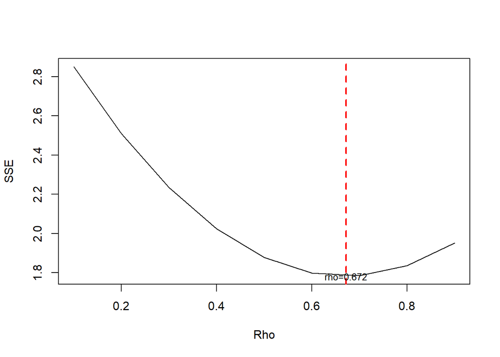

```r
#Grafik SSE optimum
par(mfrow = c(1,1))
plot(tab$SSE ~ tab$rho , type = "l", xlab = "Rho", ylab = "SSE")
abline(v = tabOpt[tabOpt$SSE==min(tabOpt$SSE),"rho"], lty = 2, col="red",lwd=2)
text(x=0.672, y=1.782725, labels = "rho=0.672", cex = 0.8)
```

nilai optimum yaitu saat SSE terkecil terdapat pada nilai p=0.672. hal tsb jg ditunjukkan pada plot

```r
model_hl <- hildreth.lu(data$IPM, data$Tahun, rho = 0.672)
summary(model_hl)
```

```
##
## Call:
## lm(formula = y ~ x)
##
## Residuals:
##      Min       1Q   Median       3Q      Max
## -0.58781 -0.32854  0.01932  0.17880  0.92429
##
## Coefficients:
##              Estimate Std. Error t value Pr(>|t|)
## (Intercept) -343.1634    71.3418  -4.810 0.000713 ***
## x              0.5525     0.1076   5.133 0.000442 ***
## ---
## Signif. codes:  0 '***' 0.001 '**' 0.01 '*' 0.05 '.' 0.1 ' ' 1
##
## Residual standard error: 0.4222 on 10 degrees of freedom
## Multiple R-squared:  0.7249, Adjusted R-squared:  0.6974
## F-statistic: 26.35 on 1 and 10 DF,  p-value: 0.0004423
```

Menunjukkan bahwa nilai p optimum yaitu saat SSE terkecil terdapat pada nilai p = 0.672 hal tersebut ditunjukkan pada plot. Selanjutnya model didapatkan dengan evaluasi nilai p ke dalam fungsi. serta dilanjutkan dgn pengujian autokorelasi dgn uji Durbin-Watson.

```r
#Transformasi Balik
cat("y = ", coef(model_hl)[1]/(1-0.672), "+", coef(model_hl)[2],"x", sep = "")
```

```
## y = -1046.23+0.5525379x
```

```r
#Deteksi autokorelasi
dwtest(model_hl)
```

```
##
##  Durbin-Watson test
##
## data:  model_hl
## DW = 1.7152, p-value = 0.1863
## alternative hypothesis: true autocorrelation is greater than 0
```

Hasil uji Durbin-Watson juga menunjukkan bawah nilai DW sebesar 1.7152 berada pada selang daerah tidak ada autokorelasi Hal tersebut juga didukung oleh p-value sebesar 0.1863, di mana p-value > α=5%. Artinya tak tolak H0 atau belum cukup bukti menyatakan bahwa ada autokorelasi dalam data nilai IPM dengan metode Hildreth-Lu pada taraf nyata 5%.

```r
# Menghitung SSE untuk setiap model secara manual
sse_awal <- sum(residuals(model)^2)
sse_co <- sum(residuals(modelCO)^2)
sse_hl <- sum(residuals(model_hl)^2)

# Membuat tabel perbandingan
data.frame(
  Metode = c("Model Awal", "Cochrane-Orcutt", "Hildreth-Lu"),
  SSE = c(sse_awal, sse_co, sse_hl),
  DW_Statistic = c(dwtest(model)$statistic, modelCO$DW[3], dwtest(model_hl)$statistic)
)
```

```
##            Metode      SSE DW_Statistic
## 1      Model Awal 3.503694    0.6689784
## 2 Cochrane-Orcutt 6.296753    1.7147977
## 3     Hildreth-Lu 1.782725    1.7151511
```

# Simpulan

Terlihat bahawa Model awal SSE sedang, tapi DW sgt jauh dri 2 maka indikasi autokorelasi positif kuat (model sakit)

Pada Cochrane-Orcutt terlihat bahwa DW mendekati 2 maka autokorelasinya berkurang tetapi SSE justru meningkat cukup besar maka model kurang efisien

Hildreth-Lu terlihat bahwa SSE paling kecil dan dw mendakit 2 maka autokorelasi terkoreksi (model yg paling baik)

maka model yg baik digunakan adalah model Hildret-Lu